# 혼자 공부하는 머신러닝 딥러닝

2021

## 03-2. 선형회귀 (Linear Regression)

## Simple linear regression

\(f(x_i) = Y_i = \beta_0 + \beta_1X_{i} + \epsilon_{i}, \ \ for \ i = 1,2, ..., n\)  
- \(\small \epsilon_{i} \sim^{i.i.d} N(0, \sigma^2), \ \forall i\)  
- \(\small Independency, \ Normality, \ Homoscedasticity\)

```r
head(ames[, c("Sale_Price", "Gr_Liv_Area")], n = 10)
```

```
# A tibble: 10 x 2
   Sale_Price Gr_Liv_Area
        <int>       <int>
 1     215000        1656
 2     105000         896
 3     172000        1329
 4     244000        2110
 5     189900        1629
 6     195500        1604
 7     213500        1338
 8     191500        1280
 9     236500        1616
10     189000        1804
```

## Scatter plot

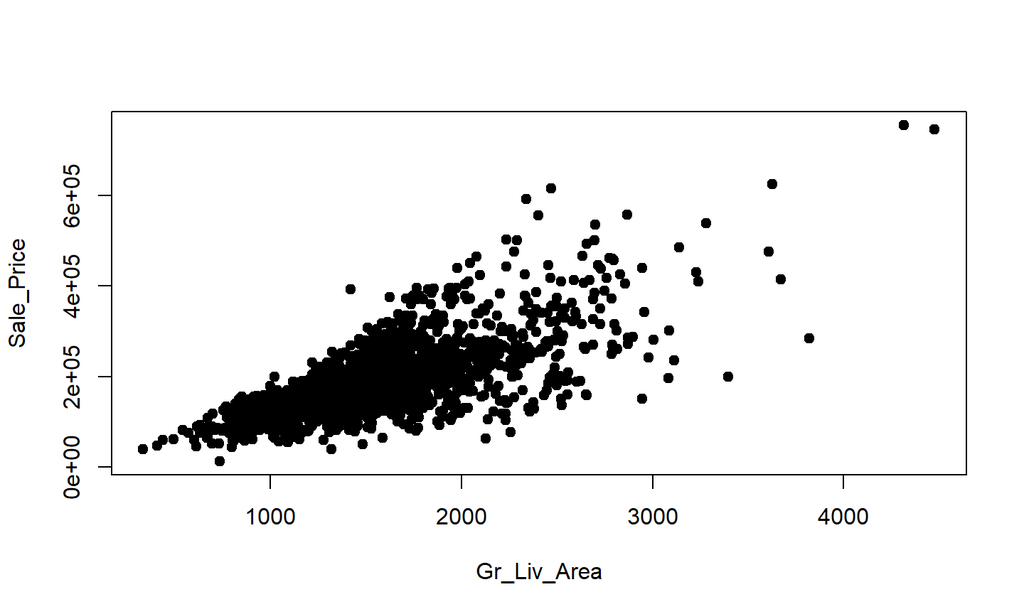

```r
plot(Sale_Price ~ Gr_Liv_Area, data = ames_train, pch = 19, cex = 1)
```

## Parameter estimation

- OLS estimation

\(\frac{\partial{SSE}}{\partial{\hat{\beta_0}}} = 0, \ \ \ \hat{\beta_0} = \overline{y} - \hat{\beta_1}\overline{x}\)

\(\frac{\partial{SSE}}{\partial{\hat{\beta_1}}} = 0,\ \ \ \hat{\beta_1} = \frac{\sum_i^n(x_i-\overline{x})(y_i-\overline{y})}{\sum_i^n(x_i-\overline{x})^2}\)  
- \(\small \sum_i^n(x_i-\overline{x})(y_i-\overline{y}) = S_{xy}\)  
- \(\small \sum_i^n(x_i-\overline{x})^2 = S_{xx}\)

## Multiple linear regression

\(f(x_i) = Y_i = \beta_0 + \beta_1X_{1i} + \beta_2X_{2i} + \epsilon_{i}, \ \ for \ i = 1,2, ..., n\)  
- \(\small \epsilon_{i} \sim^{i.i.d} N(0, \sigma^2), \ \forall i\) - \(\small \beta^TX = \beta_0 + \beta_1X_{1i} + \beta_2X_{2i}\)

```r
head(ames[, c("Sale_Price", "Gr_Liv_Area", "Year_Built")], n = 6)
```

```
# A tibble: 6 x 3
  Sale_Price Gr_Liv_Area Year_Built
       <int>       <int>      <int>
1     215000        1656       1960
2     105000         896       1961
3     172000        1329       1958
4     244000        2110       1968
5     189900        1629       1997
6     195500        1604       1998
```

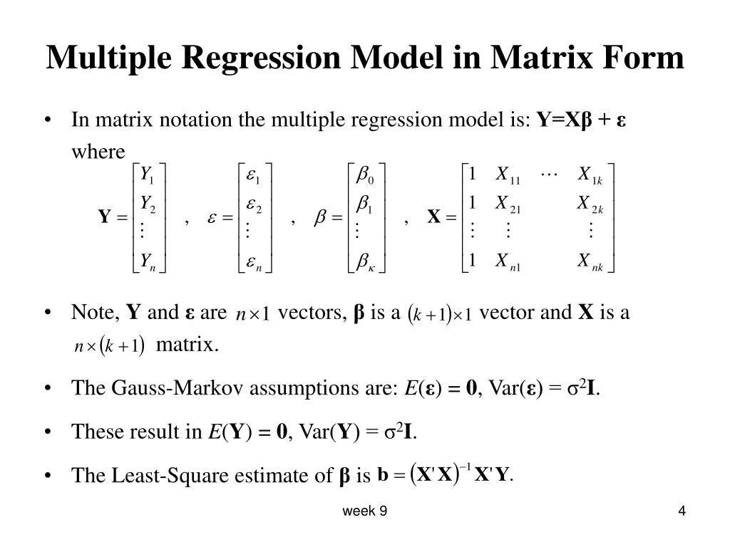

https://www.slideserve.com/verne/analysis-of-variance-in-matrix-form

## OLS of Multiple linear regression

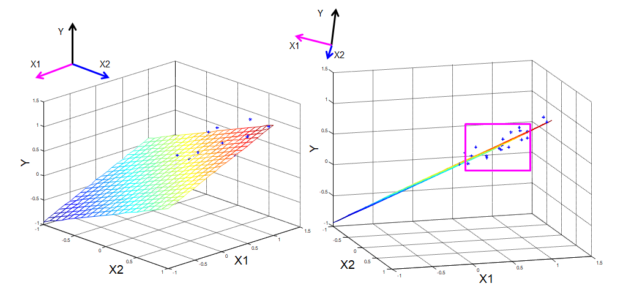

## 03-3. 특성공학과 규제 (Feature engineering and regularization)

## Regularization 목적

- 과적합 방지
- 모델 파라메터 수를 조정 (단순한 모델)

## 주로 사용하는 penalty parameters

- Ridge (L2 Norm)
- LASSO (L1 Norm, Least absolute shrinkage and selection operator)
- Elastic net (L1 + L2 Norm)

## How to effect on parameter estimation

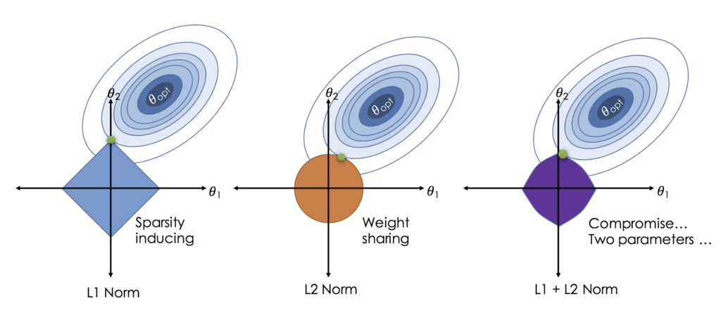

https://soobarkbar.tistory.com/30

## Overview of OLS

min\(SSE = \sum_{i = 1}^n(y_i - \hat y_i)^2\)

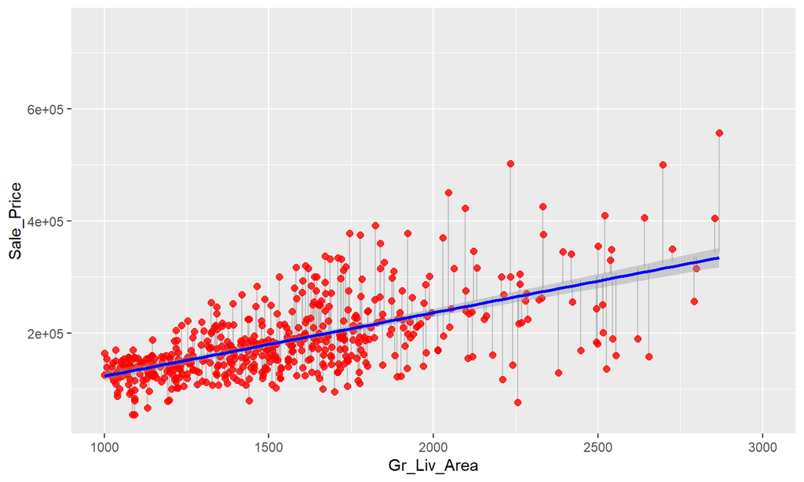

## Ridge penalty

\(J(\beta) = min(SSE \ + \lambda\sum_{j = 1}^p\beta_j^2)\)

- When \(λ=0\), there is no effect, equals to the normal OLS regression objective function
- As \(λ → ∞\), the penalty becomes large and forces the coefficients toward zero.

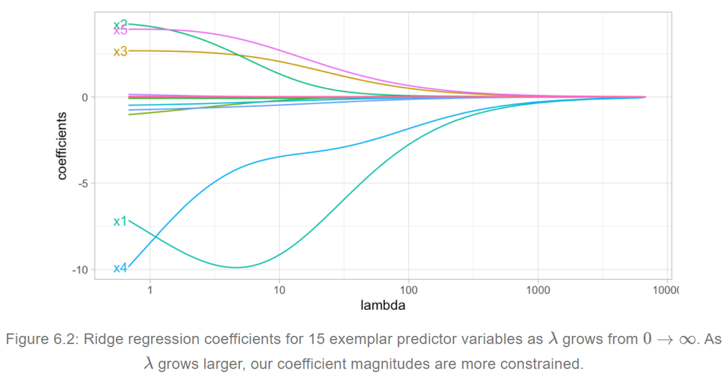

  https://bradleyboehmke.github.io/HOML

## LASSO penalty

\(J(\beta) = min(SSE \ + \lambda\sum_{j = 1}^p |\beta_j|)\)

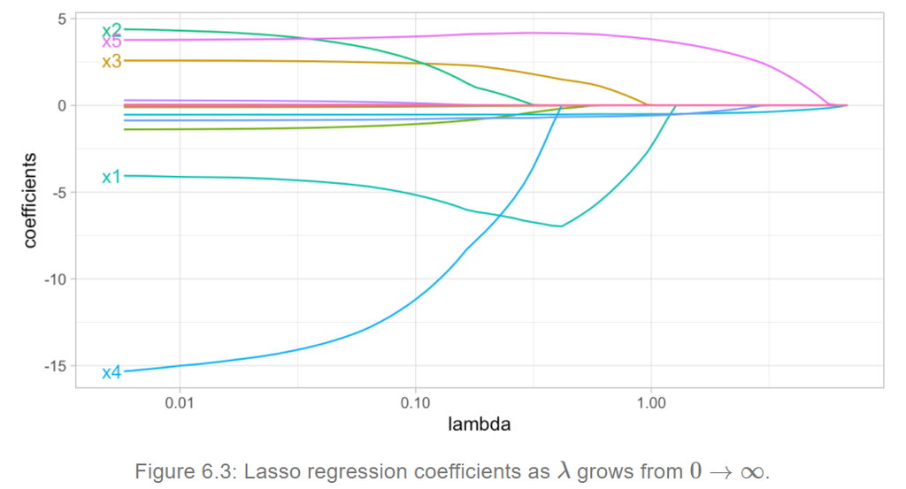

https://bradleyboehmke.github.io/HOML

## 04-1. 로지스틱 회귀 (Logistic regression)

## Why logistic regression

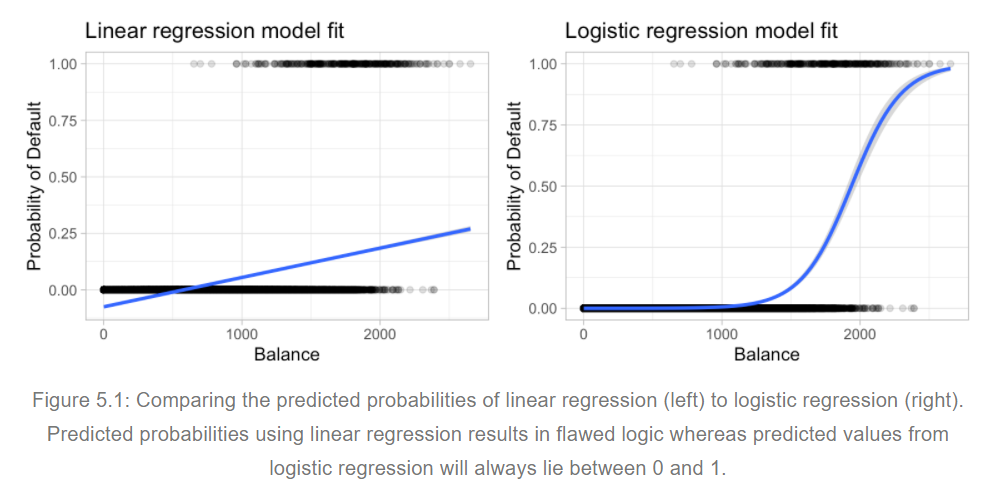

https://bradleyboehmke.github.io/HOML

## Multiple logistic regression

- Formula extend  
  \(p(X) = \frac{e^{\beta_0+\beta_1X_1+...+\beta_pX_p}}{1+ e^{\beta_0+\beta_1X_1+...+\beta_pX_p}} = \frac{1}{1 + e^{-(\beta_0+\beta_1X_1+...+\beta_pX_p)}}\)
- Logit transformation  
  \(g(X) = ln[\frac{p(x)}{1-p(x)}] = \beta_0 + \beta_1X+...+\beta_pX_p\)

## Logistic estimation

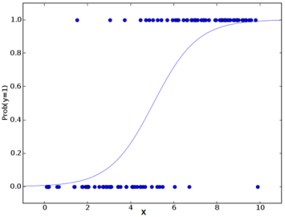

https://www.analyticsvidhya.com/blog/2015/11/beginners-guide-on-logistic-regression-in-r/

## 04-2 확률적 경사 하강법 (Stochastic gradient descent)

## Derivatives of cost function of logistic regression

Let’s see the cases of cost function of logistic regression  
This equation does not have a closed-form solution

\(J(\theta) = -\frac{1}{m}\sum_{i= 1}^m[y_ilog(h_\theta(x_i)) +(1-y_i)log(1- h_\theta(x_i))\)  
*where*, \(h_\theta(x_i) = \frac{1}{1+e^{-\theta x}}, \ \ y \in {0, 1}\)

## The concept of gradient descent (GD) algorithm

```
# A tibble: 5 x 2
  speed  dist
  <dbl> <dbl>
1     0    12
2     2    16
3     3    10
4     6    20
5     4    22
```

```
(Intercept)       speed
       11.5         1.5
```

```
[1] "Sum of squard error =  59"
```

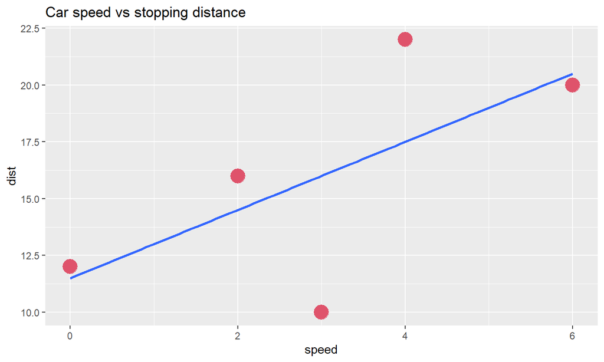

## Gradient descent (GD) algorithm

- Objective (cost) function =  
  \(\small J(\theta) = \frac{1}{2m}\sum_{i = 1}^{m}(h_\theta(x_i) - y_i)^2\)  
  \(\small =\frac{1}{2m}\sum_{i = 1}^{m}(y_i - h_\theta(x_i))^2\)
- Parameter update :  
  Repeat until convergence {  
  \(\small \theta_j^{(n+1)} = \theta_j^{(n)} - \gamma \frac{\partial}{\partial \theta_j}J( \theta^{(n)})\)  
  }

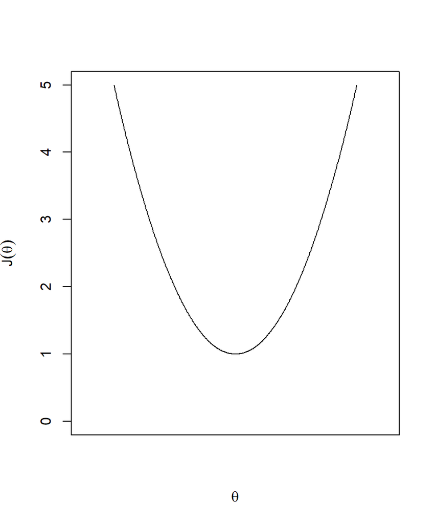

## 05-1. 결정트리

## Structure

- Decision tree for conditions to play tennis

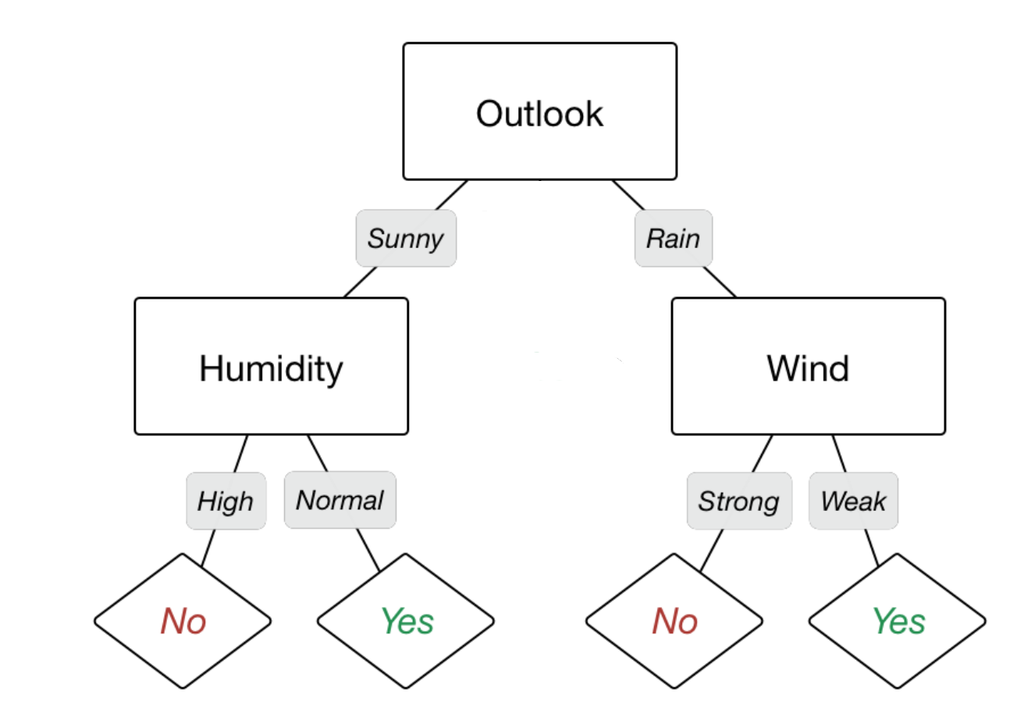

  https://medium.com/@anshulraghav2222/decision-tree-classification-9390d6038ac8

## Partitioning rule of classification case

- Maximize the reduction in cross-entropy or the Gini index
  - Gini index: \(I_G=1-\sum_{j=1}^{c}p_j^2\), \(\small c\) is number of class
  - Entropy: \(Entropy(p_j) =-\sum_{j=1}^cp_jlog(p_j)\)

    | Disease | Hypertension | chestPain | Cholesterol |
    | --- | --- | --- | --- |
    | Yes | No | Yes | 208 |
    | Yes | No | No | 282 |
    | Yes | No | Yes | 235 |
    | No | Yes | Yes | 277 |
    | Yes | No | Yes | 280 |
    | No | Yes | Yes | 242 |
    | No | No | No | 275 |
    | No | Yes | No | 214 |
    | Yes | Yes | Yes | 231 |
    | Yes | Yes | No | 206 |

## Ginni and Entropy

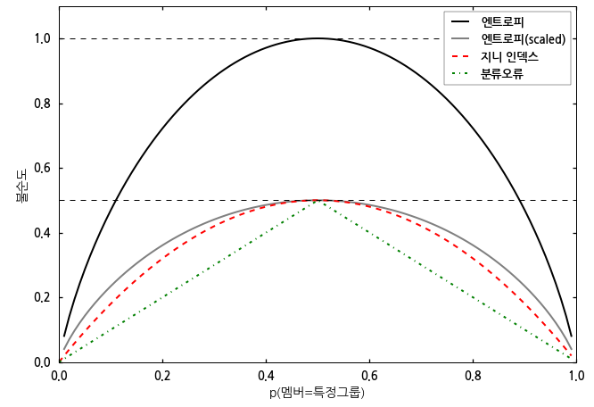

https://m.blog.naver.com/samsjang/220978650404

## 05-3. 트리의 앙상블

## What is Random forest (RF)

- Bootstrap aggregating (Bagging) + Split-variable randomization

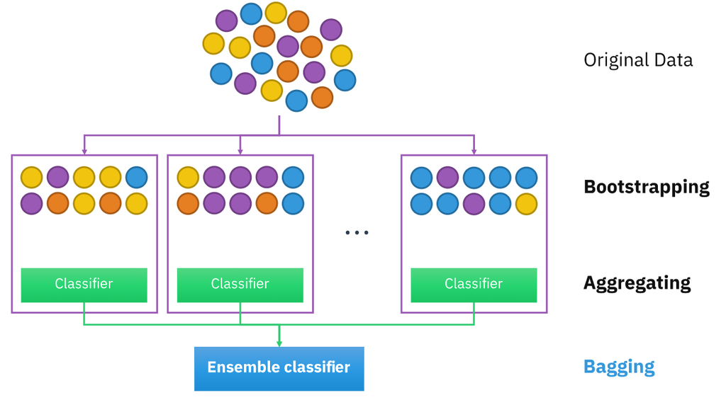

https://en.wikipedia.org/wiki/Bootstrap_aggregating

## Illustration of RF

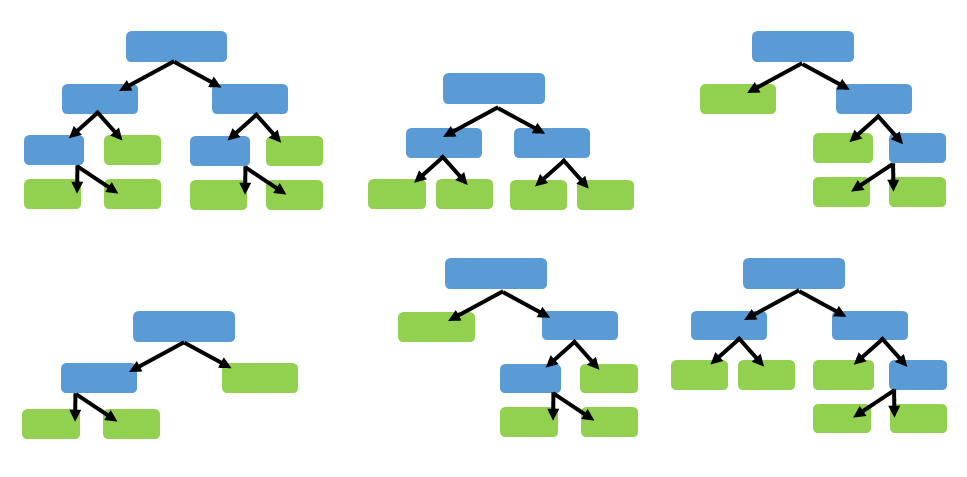

https://bradleyboehmke.github.io/HOML